# Practices_Exercise6_Starwin

## 3. In this problem, you will develop a model to predict whether a given car gets high or low gas mileage based on the Auto data set.

## (a) Create a binary variable, mpg01, that contains a 1 if mpg contains a value above its median, and a 0 if mpg contains a value below its median. You can compute the median using the median() function.

```r
data(Auto)
Auto <- na.omit(Auto)
Auto <- distinct(Auto)
Auto$mpg01 <- with(ifelse(mpg>median(mpg), "1", "0"), data= Auto)
Auto$mpg01 <- factor(Auto$mpg01)
```

## (b) Explore the data graphically in order to investigate the association between mpg01 and the other features. Which of the other features seem most likely to be useful in predicting mpg01? Scatterplots and boxplots may be useful tools to answer this question. Describe your findings.

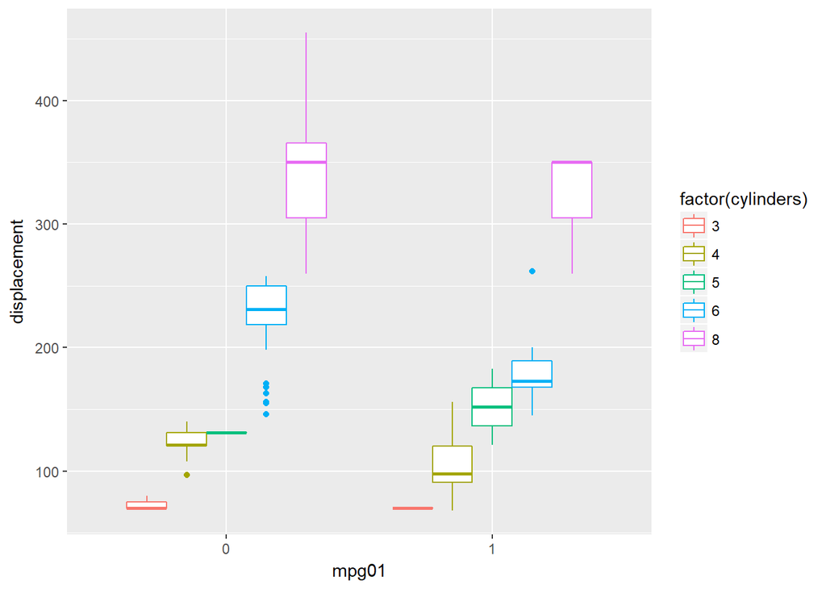

```r
ggplot(Auto, aes(mpg01, displacement, color = factor(cylinders))) + geom_boxplot()
```

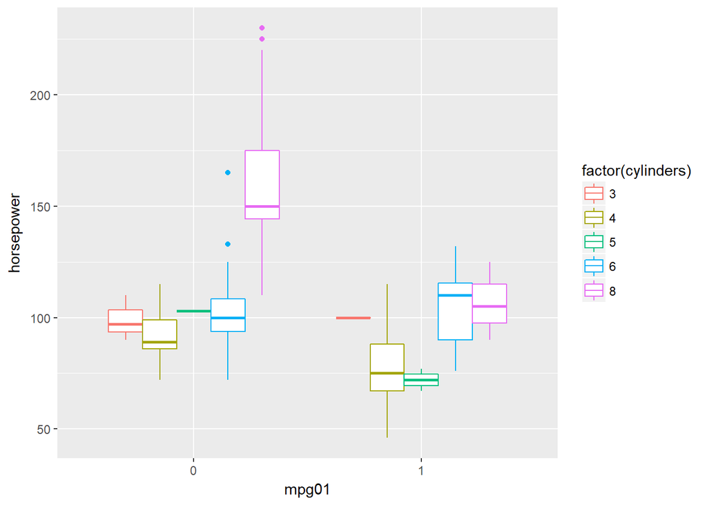

```r
ggplot(Auto, aes(mpg01, horsepower, color = factor(cylinders))) + geom_boxplot()
```

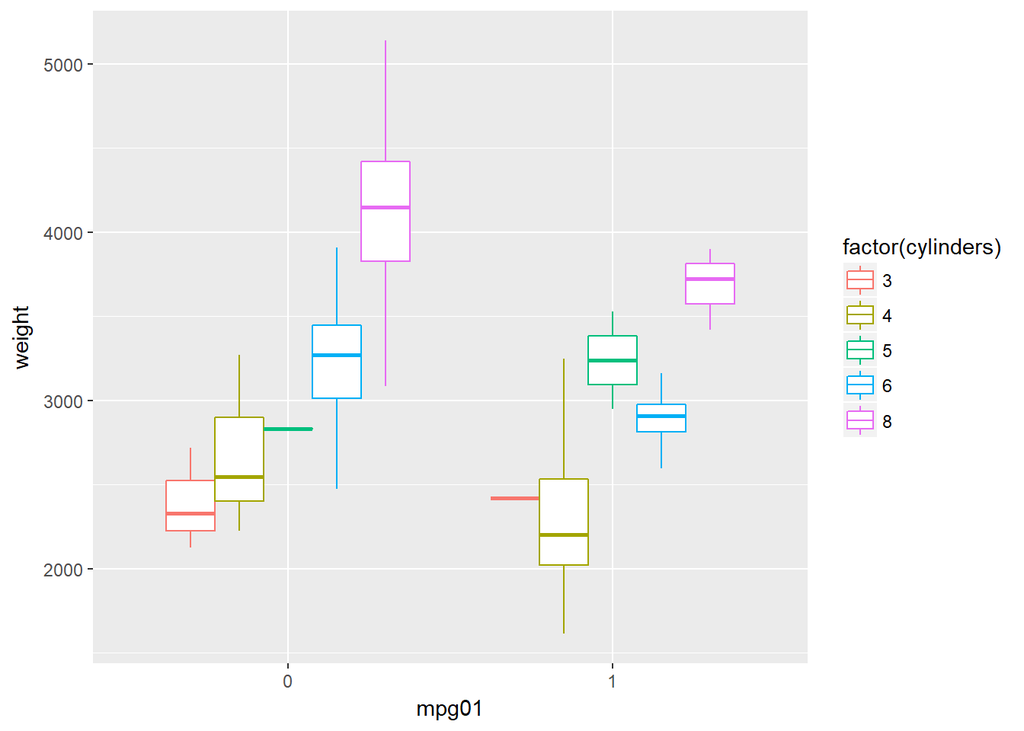

```r
ggplot(Auto, aes(mpg01, weight, color = factor(cylinders))) + geom_boxplot()
```

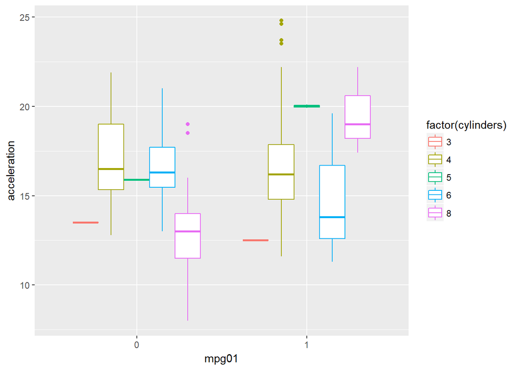

```r
ggplot(Auto, aes(mpg01, acceleration, color = factor(cylinders))) + geom_boxplot()
```

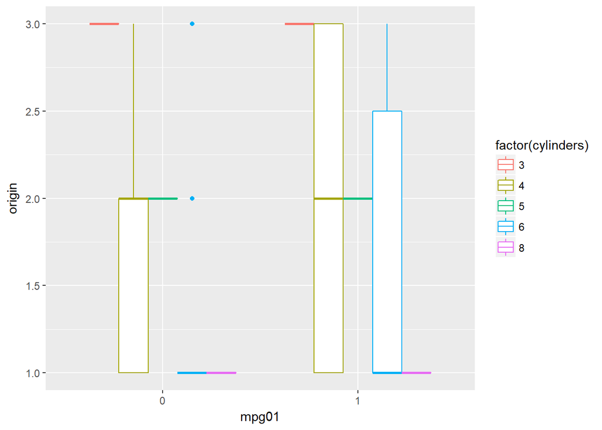

```r
ggplot(Auto, aes(mpg01, origin, color = factor(cylinders))) + geom_boxplot()
```

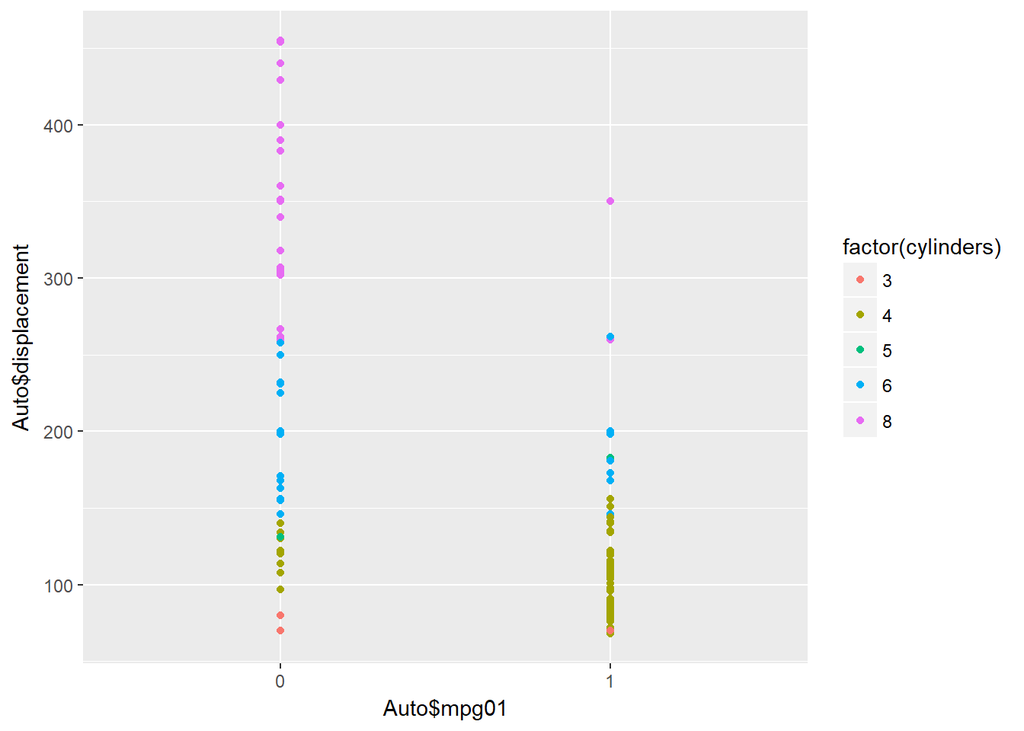

```r
ggplot(data=Auto, aes(Auto$mpg01,Auto$displacement,color=factor(cylinders))) + geom_point()
```

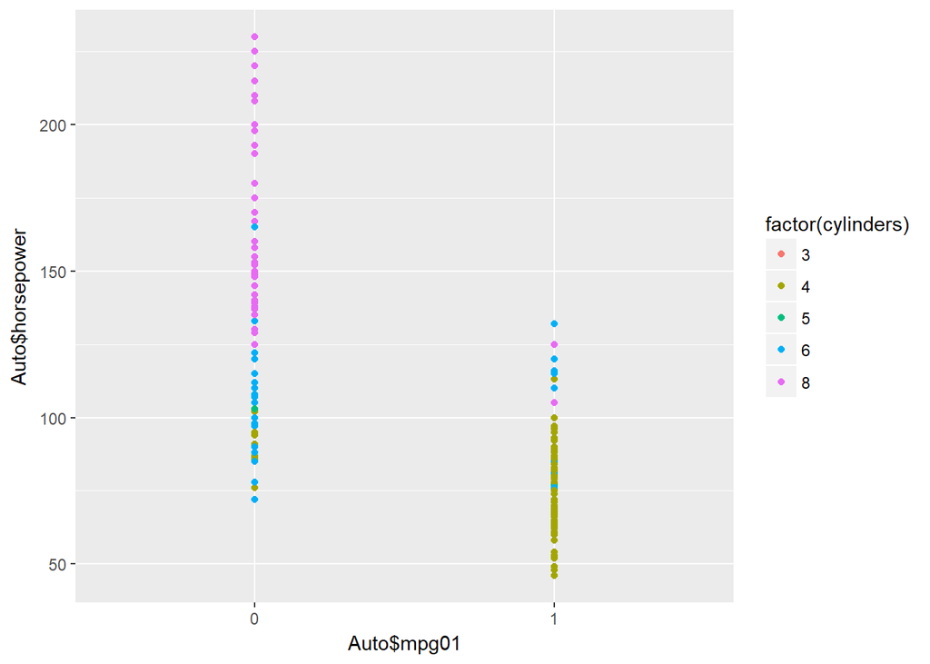

```r
ggplot(data=Auto, aes(Auto$mpg01,Auto$horsepower,color=factor(cylinders))) + geom_point()
```

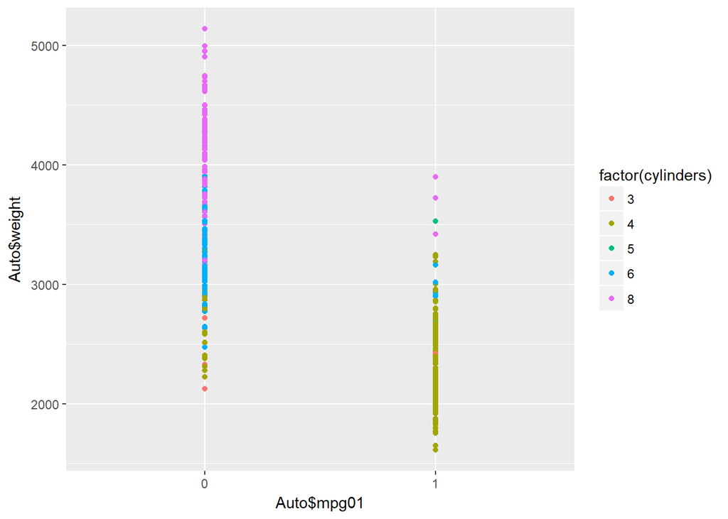

```r
ggplot(data=Auto, aes(Auto$mpg01,Auto$weight,color=factor(cylinders))) + geom_point()
```

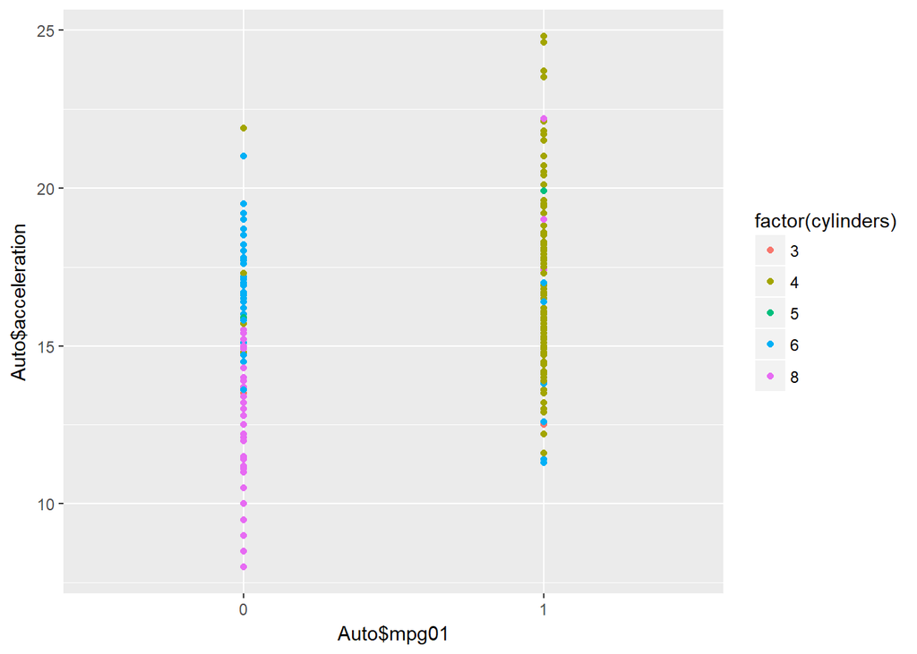

```r
ggplot(data=Auto, aes(Auto$mpg01,Auto$acceleration,color=factor(cylinders))) + geom_point()
```

## (c) Split the data into a training set and a test set.

```r
set.seed(12345)
intrain8 <- createDataPartition(Auto$mpg01,p=0.75,list = FALSE)
train8 <- Auto[intrain,]
test8 <- Auto[-intrain,]
```

## (d) Perform LDA on the training data in order to predict mpg01 using the variables that seemed most associated with mpg01 in (b). What is the test error of the model obtained?

```r
### Fit model
#modFit9 <- train(mpg01 ~ displacement+horsepower+weight+acceleration+year+cylinders+origin, method='lda',data=train8, na.action=na.pass)
#ldamodel9 <- modFit9$finalModel
#ldamodel9
library(MASS)
ldamodel9 <- lda(mpg01 ~ displacement+horsepower+weight+acceleration+year+cylinders+origin, data=train8)
lda.pred <- predict(ldamodel9, test8)
table(test8$mpg01, lda.pred$class)
```

```
##
##      0  1
##   0 50 12
##   1  2 55
```

## (e) Perform QDA on the training data in order to predict mpg01 using the variables that seemed most associated with mpg01 in (b). What is the test error of the model obtained?

```r
### Fit model
#modFit9 <- train(mpg01 ~ displacement+horsepower+weight+acceleration+year+cylinders+origin, method='lda',data=train8)
#ldamodel9 <- modFit9$finalModel
#ldamodel9
library(MASS)
qdamodel10 <- qda(mpg01 ~ displacement+horsepower+weight+acceleration+year+cylinders+origin, data=train8)
qda.pred <- predict(qdamodel10, test8)
table(test8$mpg01, qda.pred$class)
```

```
##
##      0  1
##   0 53  9
##   1  2 55
```

## (f) Perform logistic regression on the training data in order to predict mpg01 using the variables that seemed most associated with mpg01 in (b). What is the test error of the model obtained?

```r
modFit11 <- train(mpg01 ~ displacement+horsepower+weight+acceleration+year+cylinders+origin, method='glm', data=train8, family=binomial(link='logit'), na.action=na.pass)
logitmodel11 <- modFit11$finalModel
summary(logitmodel11)
```

```
##
## Call:
## NULL
##
## Deviance Residuals:
##      Min        1Q    Median        3Q       Max
## -2.18186  -0.07809   0.03263   0.24924   2.69309
##
## Coefficients:
##                Estimate Std. Error z value Pr(>|z|)
## (Intercept)  -16.968727   6.931972  -2.448   0.0144 *
## displacement  -0.014662   0.014231  -1.030   0.3029
## horsepower    -0.032559   0.028899  -1.127   0.2599
## weight        -0.003522   0.001449  -2.431   0.0151 *
## acceleration   0.042299   0.177955   0.238   0.8121
## year           0.413657   0.087408   4.732 2.22e-06 ***
## cylinders      0.108130   0.491972   0.220   0.8260
## origin        -0.134044   0.426973  -0.314   0.7536
## ---
## Signif. codes:  0 '***' 0.001 '**' 0.01 '*' 0.05 '.' 0.1 ' ' 1
##
## (Dispersion parameter for binomial family taken to be 1)
##
##     Null deviance: 378.37  on 272  degrees of freedom
## Residual deviance: 108.57  on 265  degrees of freedom
##   (227 observations deleted due to missingness)
## AIC: 124.57
##
## Number of Fisher Scoring iterations: 8
```

```r
#Predict model
predictions11 <- predict(modFit11, newdata = test8)
```

```r
#Check accuracy
confusionMatrix(predictions11,test8$mpg01 )
```

```
## Confusion Matrix and Statistics
##
##           Reference
## Prediction  0  1
##          0 56  5
##          1  6 52
##
##                Accuracy : 0.9076
##                  95% CI : (0.8406, 0.9529)
##     No Information Rate : 0.521
##     P-Value [Acc > NIR] : <2e-16
##
##                   Kappa : 0.8149
##  Mcnemar's Test P-Value : 1
##
##             Sensitivity : 0.9032
##             Specificity : 0.9123
##          Pos Pred Value : 0.9180
##          Neg Pred Value : 0.8966
##              Prevalence : 0.5210
##          Detection Rate : 0.4706
##    Detection Prevalence : 0.5126
##       Balanced Accuracy : 0.9078
##
##        'Positive' Class : 0
##
```

```r
data("cars")
cars <- na.omit(cars)
cars <- distinct(cars)
cars$Cylinder <- factor(cars$Cylinder)
```

## Use the k-NN method to predict the number of cylinders a car’s engine would have based on the other features in the dataset.

```r
intrain13 <- createDataPartition(cars$Cylinder,p=0.75,list = FALSE)
train13 <- cars[intrain13,]
test13 <- cars[-intrain13,]
trctrl <- trainControl(method = "cv", number = 10)
set.seed(3333)
knn_fit <- train(Cylinder ~., data = train13, method = "knn",
                 trControl=trctrl)
knn_fit
```

```
## k-Nearest Neighbors
##
## 604 samples
##  17 predictor
##   3 classes: '4', '6', '8'
##
## No pre-processing
## Resampling: Cross-Validated (10 fold)
## Summary of sample sizes: 544, 544, 543, 542, 544, 545, ...
## Resampling results across tuning parameters:
##
##   k  Accuracy   Kappa
##   5  0.8375381  0.7239224
##   7  0.8508195  0.7477871
##   9  0.8590181  0.7617206
##
## Accuracy was used to select the optimal model using the largest value.
## The final value used for the model was k = 9.
```

## Compute the accuracy of your predictions

```r
predictions13 <- predict(knn_fit, newdata = test13)
predictions13
```

```
##   [1] 4 4 4 4 6 4 4 4 4 4 4 4 4 8 4 4 4 4 4 4 8 8 4 4 4 4 8 4 4 4 6 6 6 6 6
##  [36] 4 8 4 4 6 6 6 6 6 6 6 6 4 4 6 6 6 8 8 8 8 6 6 6 8 6 4 6 4 4 4 4 4 4 4
##  [71] 4 4 6 4 4 4 4 6 6 4 4 4 4 4 4 4 4 6 6 6 6 6 6 4 4 4 6 6 6 6 6 4 6 6 6
## [106] 4 4 4 6 6 6 8 8 8 8 4 4 4 4 8 4 4 4 4 6 6 6 6 6 6 4 4 4 4 4 6 6 6 4 6
## [141] 6 6 4 8 4 8 8 8 4 4 4 6 6 8 8 6 6 6 6 6 6 6 8 6 6 4 4 6 4 4 4 6 4 4 4
## [176] 4 6 4 6 4 6 4 6 6 6 8 4 8 4 4 4 4 6 6 4 6 6 6 4 4
## Levels: 4 6 8
```

```r
confusionMatrix(predictions13,test13$Cylinder)
```

```
## Confusion Matrix and Statistics
##
##           Reference
## Prediction  4  6  8
##          4 86  9  3
##          6  9 67  2
##          8  3  1 20
##
## Overall Statistics
##
##                Accuracy : 0.865
##                  95% CI : (0.8097, 0.9091)
##     No Information Rate : 0.49
##     P-Value [Acc > NIR] : <2e-16
##
##                   Kappa : 0.773
##  Mcnemar's Test P-Value : 0.9536
##
## Statistics by Class:
##
##                      Class: 4 Class: 6 Class: 8
## Sensitivity            0.8776   0.8701   0.8000
## Specificity            0.8824   0.9106   0.9771
## Pos Pred Value         0.8776   0.8590   0.8333
## Neg Pred Value         0.8824   0.9180   0.9716
## Prevalence             0.4900   0.3850   0.1250
## Detection Rate         0.4300   0.3350   0.1000
## Detection Prevalence   0.4900   0.3900   0.1200
## Balanced Accuracy      0.8800   0.8903   0.8886
```

## Get the jersey city shooting data from blackboard

```r
jerseycity <- read.csv("C:/Users/starw/OneDrive/Documents/NJCU Spring Semester/FINC614_Intro to Data science/Data Sets/jerseycity2015shootings-use.csv")
```

## Extract the latitude and longitude columns into a data frame

```r
#jerseycityextracted <- subset(jerseycity, select = c(4, 5))
jerseycityextracted <- jerseycity[ , c("latitude", "longitude")]
```

## Perform a k means clustering with three clusters to see if the shootings cluster by location. Try 4 clusters. Which one seems better?

```r
jerseycityclusters <- kmeans(jerseycityextracted, centers = 3)
jerseycityclusters$centers
```

```
##   latitude longitude
## 1 40.71338 -74.07820
## 2 40.72579 -74.06703
## 3 40.70053 -74.08763
```

```r
jerseycityclusters$cluster
```

```
##  [1] 1 3 3 1 1 3 3 3 2 1 1 3 1 2 1 3 1 3 2 3 1 1 1 2 2 2 3 3 1 2 2 2 2 1 1
## [36] 3 1 1 1 1 1 1 2 3 3 3 1 1 3 1 3 2 1 3 2 2 1 2 1 2 1 1 1 3 1 1 1 3 1 3
## [71] 3 3 1 1 1 3 2 1 1 2 2 3 1 1 1 3
```

```r
jerseycityclusters$size
```

```
## [1] 41 19 26
```

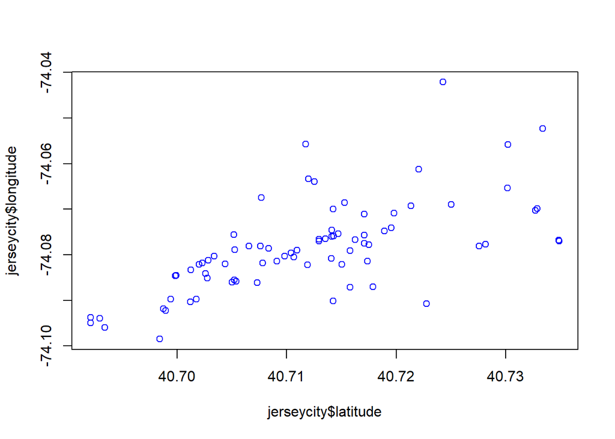

```r
plot(jerseycity$latitude, jerseycity$longitude, col = "blue")
text(jerseycity$latitude+ 0.1, jerseycity$longitude+ 0.1, labels = as.character(jerseycityclusters$cluster))
```

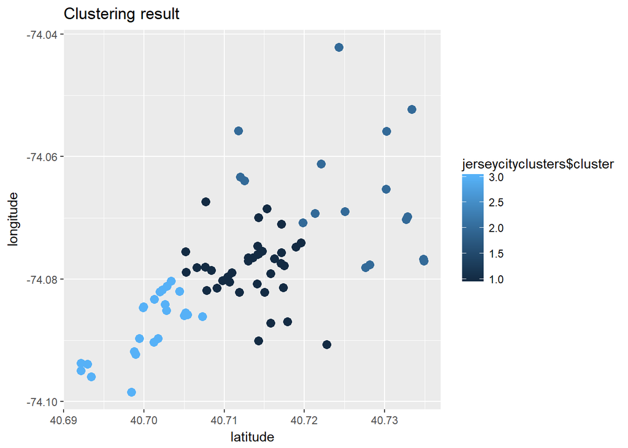

```r
library(ggplot2)
ggplot(data=jerseycity, aes(x=latitude, y=longitude, color=jerseycityclusters$cluster)) +
  geom_point(size=3) +
  ggtitle("Clustering result") + xlab("latitude") + ylab("longitude")
```

```r
jerseycityclusters4 <- kmeans(jerseycityextracted, centers = 4)
jerseycityclusters4$centers
```

```
##   latitude longitude
## 1 40.70600 -74.08204
## 2 40.71725 -74.07701
## 3 40.72558 -74.06370
## 4 40.69709 -74.09296
```

```r
jerseycityclusters4$cluster
```

```
##  [1] 2 1 1 1 2 1 1 4 2 1 1 4 1 3 1 4 2 4 3 4 2 2 2 2 3 3 1 1 1 3 3 2 3 2 2
## [36] 4 2 1 1 2 1 1 2 4 1 1 1 1 4 2 4 3 2 1 3 3 2 3 2 3 2 2 2 4 2 2 2 1 2 1
## [71] 1 4 2 1 2 1 3 2 2 3 2 1 2 2 1 1
```

```r
jerseycityclusters4$size
```

```
## [1] 29 32 14 11
```

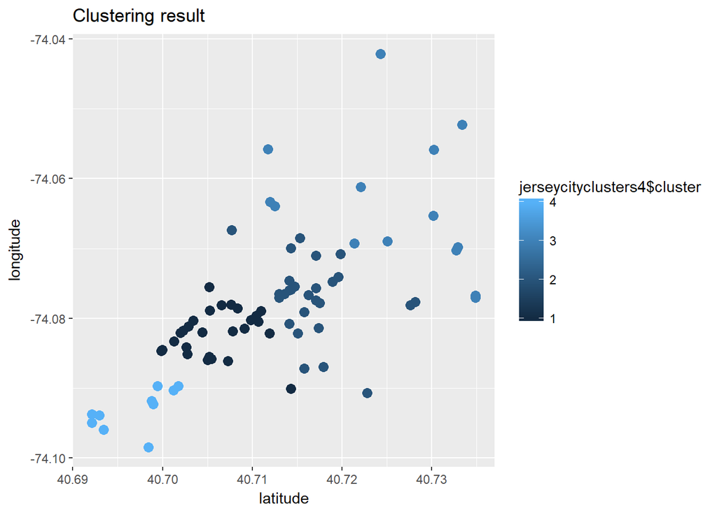

```r
library(ggplot2)
ggplot(data=jerseycity, aes(x=latitude, y=longitude, color=jerseycityclusters4$cluster)) +
  geom_point(size=3) +
  ggtitle("Clustering result") + xlab("latitude") + ylab("longitude")
```

### Observation: 4 cluster is better than 3 clsuter.

## Use the USArrests dataset in base R

```r
data("USArrests")
```

## (a) Using hierarchical clustering with complete linkage and Euclidean distance, cluster the states.

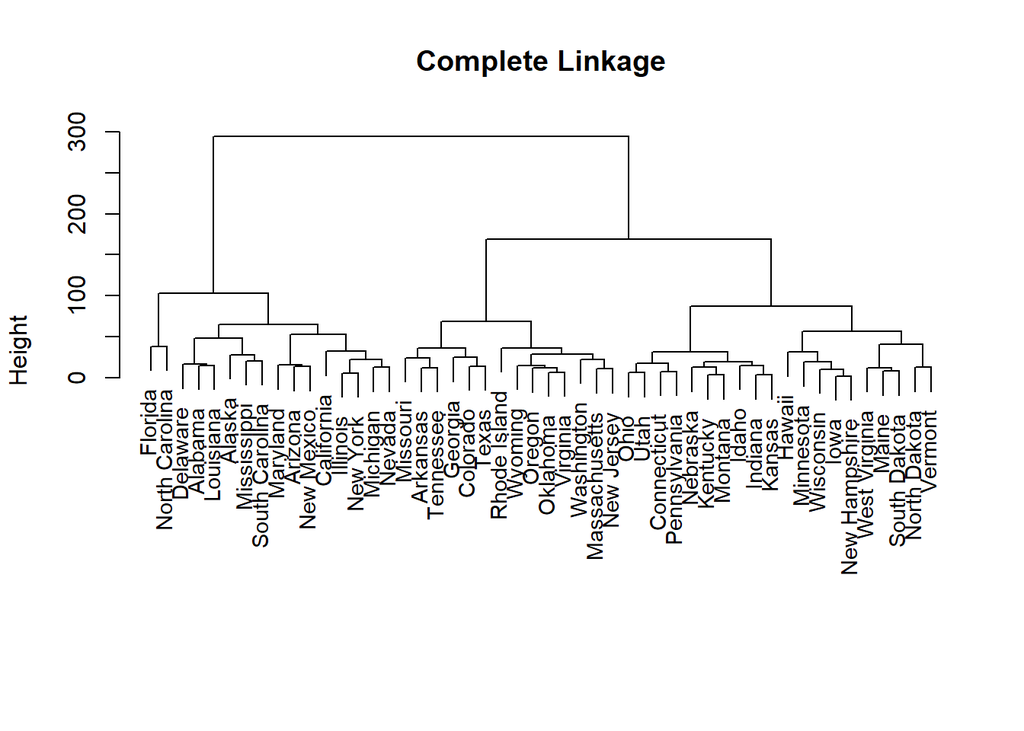

```r
d <- dist(USArrests, method = "euclidean") # distance matrix
hclustering <- hclust(d, method="complete")
clusters <- cutree(hclustering, 3)
clust_1 <- clusters[clusters == 1]; # pull out the names of the states
clust_2 <- clusters[clusters == 2];
clust_3 <- clusters[clusters == 3]
plot(hclustering,main="Complete Linkage", xlab="", sub="", cex=.9)
```

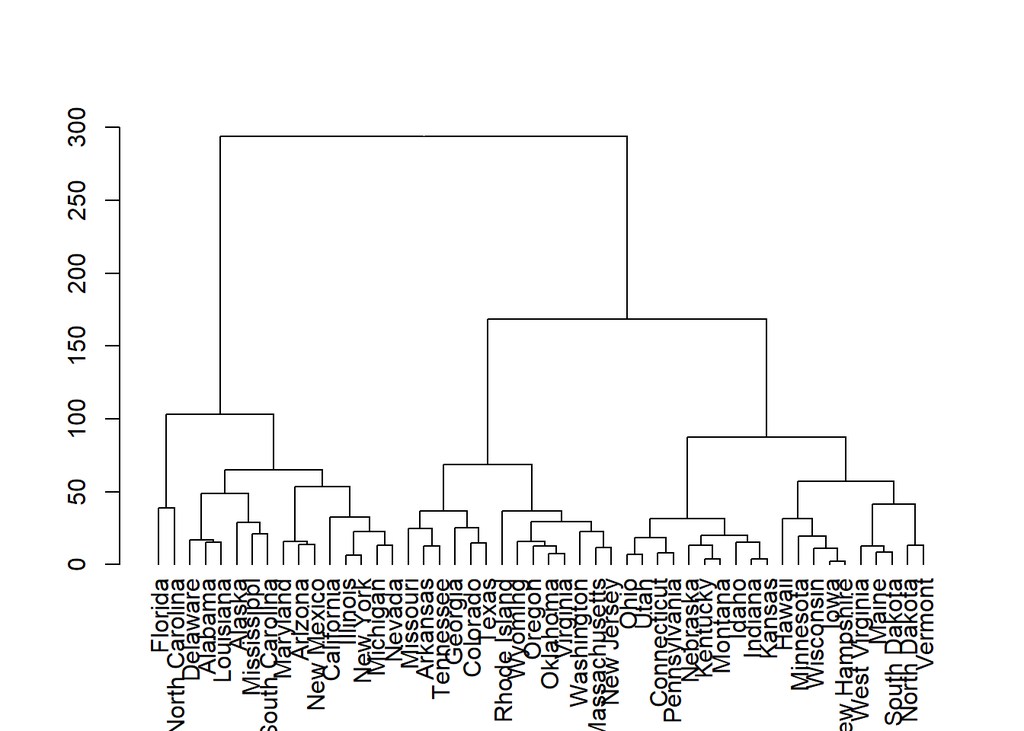

```r
hcd <- as.dendrogram(hclustering)
plot(hcd)
```

## (b) Cut the dendrogram at a height that results in three distinct clusters. Which states belong to which clusters?

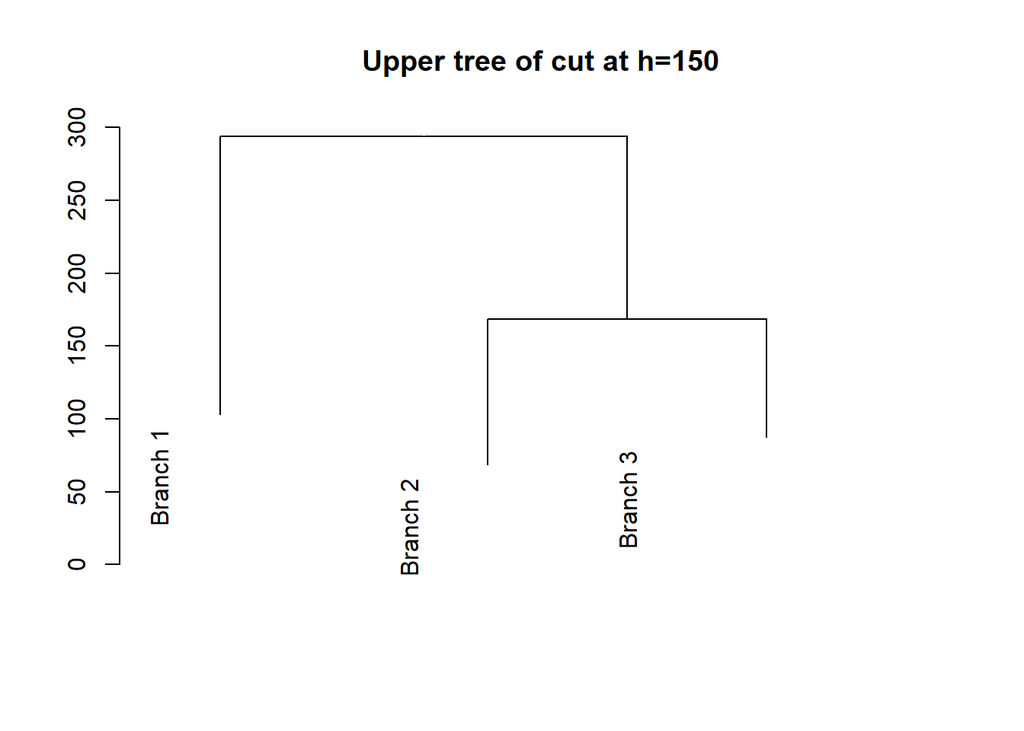

```r
plot(cut(hcd, h = 150)$upper, main = "Upper tree of cut at h=150")
```

```r
names(clust_1)
```

```
##  [1] "Alabama"        "Alaska"         "Arizona"        "California"
##  [5] "Delaware"       "Florida"        "Illinois"       "Louisiana"
##  [9] "Maryland"       "Michigan"       "Mississippi"    "Nevada"
## [13] "New Mexico"     "New York"       "North Carolina" "South Carolina"
```

```r
names(clust_2)
```

```
##  [1] "Arkansas"      "Colorado"      "Georgia"       "Massachusetts"
##  [5] "Missouri"      "New Jersey"    "Oklahoma"      "Oregon"
##  [9] "Rhode Island"  "Tennessee"     "Texas"         "Virginia"
## [13] "Washington"    "Wyoming"
```

```r
names(clust_3)
```

```
##  [1] "Connecticut"   "Hawaii"        "Idaho"         "Indiana"
##  [5] "Iowa"          "Kansas"        "Kentucky"      "Maine"
##  [9] "Minnesota"     "Montana"       "Nebraska"      "New Hampshire"
## [13] "North Dakota"  "Ohio"          "Pennsylvania"  "South Dakota"
## [17] "Utah"          "Vermont"       "West Virginia" "Wisconsin"
```

## (c) Hierarchically cluster the states using complete linkage and Euclidean distance, after scaling the variables to have standard deviation one.

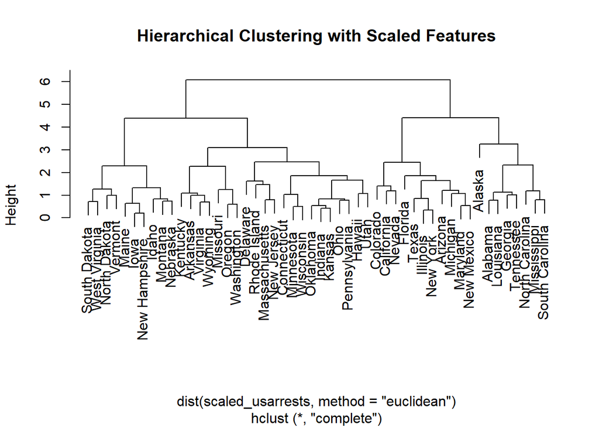

```r
scaled_usarrests <- scale(USArrests)
hc_scaled <- hclust(dist(scaled_usarrests, method = "euclidean"), method="complete")
plot(hc_scaled, main="Hierarchical Clustering with Scaled Features")
```

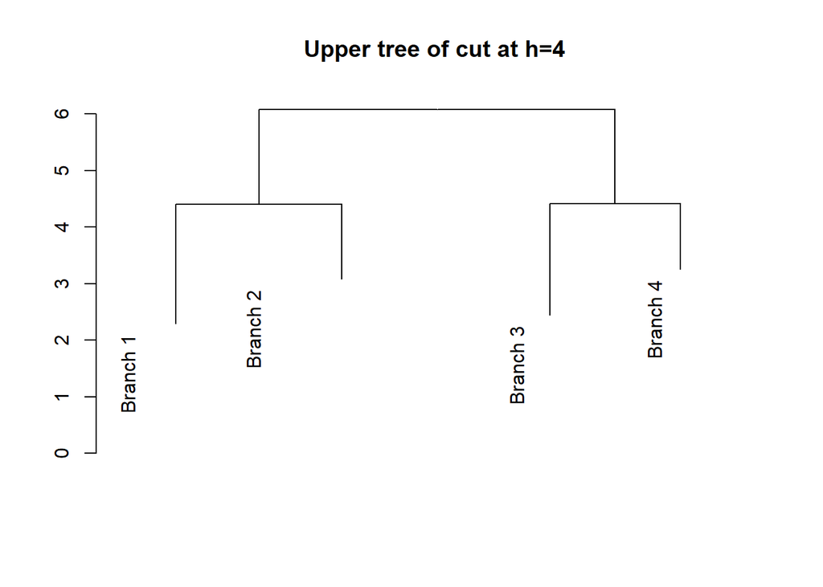

```r
hcd1 <- as.dendrogram(hc_scaled)
plot(cut(hcd1, h = 4)$upper, main = "Upper tree of cut at h=4")
```

```r
scaled_clusters <- cutree(hc_scaled, 3)
clust_1 <- scaled_clusters[scaled_clusters == 1]; # pull out the names of the states
clust_2 <- scaled_clusters[scaled_clusters == 2];
clust_3 <- scaled_clusters[scaled_clusters == 3]
names(clust_1)
```

```
## [1] "Alabama"        "Alaska"         "Georgia"        "Louisiana"
## [5] "Mississippi"    "North Carolina" "South Carolina" "Tennessee"
```

```r
names(clust_2)
```

```
##  [1] "Arizona"    "California" "Colorado"   "Florida"    "Illinois"
##  [6] "Maryland"   "Michigan"   "Nevada"     "New Mexico" "New York"
## [11] "Texas"
```

```r
names(clust_3)
```

```
##  [1] "Arkansas"      "Connecticut"   "Delaware"      "Hawaii"
##  [5] "Idaho"         "Indiana"       "Iowa"          "Kansas"
##  [9] "Kentucky"      "Maine"         "Massachusetts" "Minnesota"
## [13] "Missouri"      "Montana"       "Nebraska"      "New Hampshire"
## [17] "New Jersey"    "North Dakota"  "Ohio"          "Oklahoma"
## [21] "Oregon"        "Pennsylvania"  "Rhode Island"  "South Dakota"
## [25] "Utah"          "Vermont"       "Virginia"      "Washington"
## [29] "West Virginia" "Wisconsin"     "Wyoming"
```

## (d) What effect does scaling the variables have on the hierarchical clustering obtained? In your opinion, should the variables be scaled before the inter-observation dissimilarities are computed? Provide a justification for your answer.

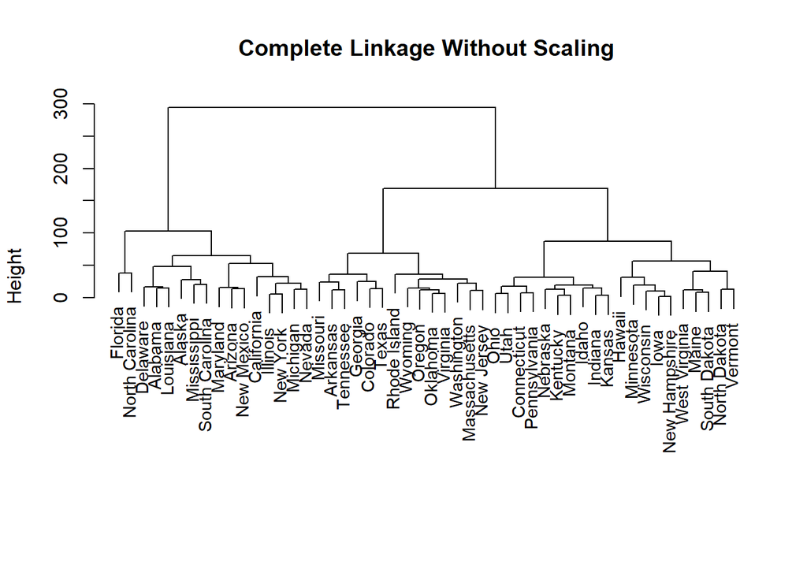

```r
plot(hclustering,main="Complete Linkage Without Scaling", xlab="", sub="", cex=.9)
```

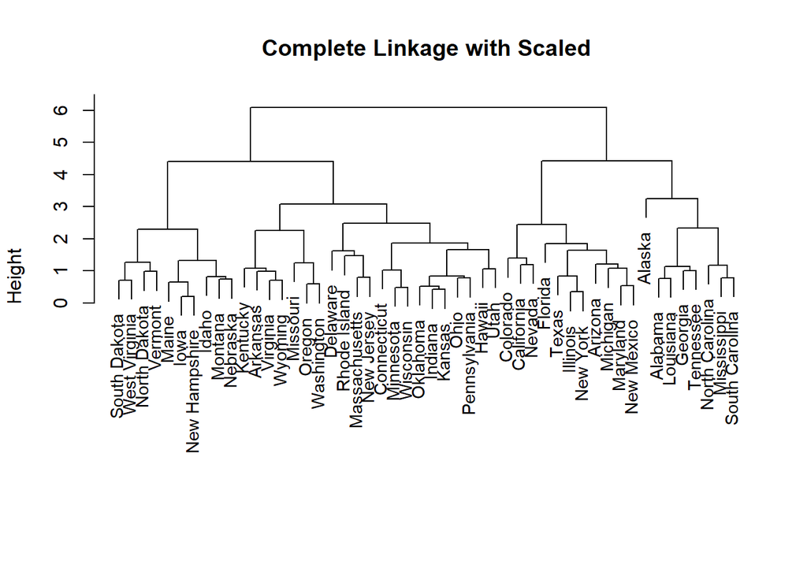

```r
plot(hc_scaled, main="Complete Linkage with Scaled", xlab = "", sub = "", cex = 0.9)
```